Estadística 1 | 2020

# Guía de Clase del TP7: Análisis de datos categóricos

Docentes: Patricia M. Acetta y Agustin Alesso

# Objetivos

En éste TP veremos el análisis de datos categóricos (cualitativos o de atributo).

El objetivo principal es probar hipótesis acerca de datos categóricos que consisten en conteos de frecuencias para diferentes categorías.

- Prueba de Independencia: a través de tablas de contingencia (o tablas de frecuencias de dos factores), que incluyen conteos de frecuencia para datos categóricos ordenados en una tabla, con al menos dos renglones y al menos dos columnas. Se prueban hipótesis que las variables de renglón y de columnas son independientes unas de otras.
- Prueba de homogeneidad: a través de tablas de contingencia se prueban hipótesis de que distintas poblaciones tienen la misma proporción de algunas características.
- Bondad de Ajuste: a través de conteos de frecuencias observadas en un solo renglón o columna (llamado tabla de frecuencias de un factor), se prueban hipótesis de que los conteos de frecuencia observados concuerdan con alguna distribución específica.

Las pruebas anteriores utilizan la misma distribución $\chi^2$ (Chi cuadrada). Sus propiedades más importantes son:

1. No es simétrica
2. Los valores pueden ser 0 o positivos, pero no pueden ser negativos
3. Es diferente para cada número de grados de libertad

**Estadístico de Prueba para todas las pruebas mencionas:**

$$\chi^2 = \sum\sum { \dfrac{ \left( o_{ij} - e_{ij} \right)^2}{e_{ij}} }$$

Donde:

- $o$: frecuencia observada
- $e$: frecuencia esperada

Las pruebas no paramétricas no establecen ninguna hipótesis acerca del valor de un parámetro poblacional y ni supuestos acerca de la distribución de la población de la cual se ha extraído la muestra (distribución libre).

Se aplican cuando los supuestos no se cumplen (e.g. poblaciones no normales) o cuando la variable respuesta no se mide en escala de intervalos o de razón (e.g. datos categóricos)

## Tabla de contingencia

Una tabla de contingencia (o tabla de frecuencias de dos factores) es una tabla en la que las frecuencias corresponden a dos variables. Una variable se utiliza para categorizar filas y una segunda variable se utiliza para categorizar columnas.

*Aclaraciones:*

- margen 1 es el total de filas
- margen 2 es el total de columnas

## Corrección de Yates para la continuidad

La distribución chi cuadrada es continua, mientras que el estadístico de prueba utilizado en esta sección es discreto. Se utiliza la corrección de Yates para la continuidad en celdas con una frecuencia esperada de menos de 10 o en todas las celdas de una tabla de contingencia con dos filas y dos columnas (2x2).

# Prueba de Independencia

En una prueba de independencia, probamos la hipótesis nula de que en una tabla de contingencia, las variables de fila y de columna son independientes. (Es decir, que no hay dependencia entre las variables de fila y de columna).

**Estadístico de Prueba para todas las pruebas mencionas:**

$$\chi^2 = \sum\sum { \dfrac{ \left( o_{ij} - e_{ij} \right)^2}{e_{ij}} }$$

*Aclaraciones:*

Las frecuencias esperadas se calculan asumiendo independencia ($H_0$)

$$e_{ij} = \dfrac{n_{i \cdot} n_{\cdot j}} {n}$$

- $n_i\cdot$: total fila
- $n_{\cdot j}$: total columna
- $n$: gran total
- $r$ número de filas en una tabla de contingencia (sin incluir las etiquetas o los totales de las filas)
- $c$ número de columnas en una tabla de contingencia (sin incluir las etiquetas o los totales de las columnas)
- Grados de libertad: $(r-1)*(c-1)$

> Las pruebas de independencia con una tabla de contingencia son siempre de cola derecha.

## Ejercicio 1

La peste porcina clásica (PPC) es una de las enfermedades víricas porcinas pandémicas más perjudiciales económicamente en el mundo. Muchos gobiernos la toman muy en serio y adoptan políticas de control estrictas, que incluyen vacunación o sacrificios compulsivos y políticas de erradicación.En una granja susceptible (no vacunada) casi todos los cerdos son afectados. Produce una enfermedad generalizada, aborto y nacimiento de lechones temblorosos. La mortalidad es alta. Existe sólo un serotipo del virus y las vacunas se aplican en varias dosis. Una empresa criadora de cerdos desea probar la relaión que existe entre los animales vacunados con una y dos dosis o ninguna, y la aparición de la enfermedad en su granja. Para ello, luego de controlar la dosis de vacunación que recibieron los animales, verifica quienes desarrollaron la enfermedad y quienes no, del total de la granja.

```
         Enfermo
Dosis      no  si
  dos     890  20
  ninguna  68 490
  una     250  85
```

Responda:

1. Cuál es la variable respuesta en estudio? Cuáles son las variables de clasificación?
2. Qué tipo de prueba se pretende analizar?
3. Plantee las hipótesis correspondientes, resuelva y concluya con un nivel de significancia del 0.05.

Importamos los datos:

```r
# Datos
txt <- textConnection("
Dosis     Enfermo   Cantidad
una     si      85
dos     si      20
ninguna si      490
una     no      250
dos     no      890
ninguna no      68")

cerdos <- read.table(txt, header = T)

# Tabla frecuencias: obs (observados)
obs <- xtabs(Cantidad ~ Dosis + Enfermo, cerdos)

# Agregar márgenes (suma de filas y columnas)
addmargins(obs)
```

```
         Enfermo
Dosis       no   si  Sum
  dos      890   20  910
  ninguna   68  490  558
  una      250   85  335
  Sum     1208  595 1803
```

### Item (a).

**Cuál es la variable respuesta en estudio? Cuáles son las variables de clasificación?**

La **variable respuesta** es **cantidad de cerdos**

Las **variables de clasificación** son:

- enfermos: indicando si el animal está o no enfermo
- dosis: indicando cuantas dosis recibió el animal

### Item (b).

**Qué tipo de prueba se pretende analizar?**

Se desea hacer una prueba de Independencia, ya que se desea estudiar en una misma muestra si dos variables tienen relación, es decir si recibir vacunación tiene relación con desarrollar o no la enfermedad (una muestra, dos atributos).

### Item (c).

**Plantee las hipótesis correspondientes, resuelva y concluya con un nivel de significancia del 0.05.**

*Seguiremos los pasos de una PH:*

1. Definir las hipótesis

$H_0$: El desarrollo de la enfermedad en cerdos es **independiente** de que el animal esté vacunado

$H_1$: El desarrollo de la enfermedad en cerdos es **no es independiente** de que el animal esté vacunado

2. Determinar el valor del estadístico de prueba

Asumiendo $H_0$, cada $e_{ij}$ es el producto de probabilidades marginales, $e_{ij} = \dfrac{n_{i \cdot} n_{\cdot j}}{n}$

El estadístico de prueba es: $\chi^2 = \sum\sum { \dfrac{ \left( o_{ij} - e_{ij} \right)^2}{e_{ij}} }$

*Recordar: margen 1 es el total de filas y margen 2 es el total de columnas*

```r
# Valores esperados: esp
n <- margin.table(obs)

# vectores con los márgenes
n1 <- margin.table(obs, margin = 1)
n2 <- margin.table(obs, margin = 2)

#multiplicamos los valores de los vectores (total fila*totalcolumna/n)
esp <- (n1 %*% t(n2))/ n
esp
```

```
         Enfermo
Dosis           no       si
  dos     609.6950 300.3050
  ninguna 373.8569 184.1431
  una     224.4481 110.5519
```

```r
# Estadístico de prueba
chi_calc <- sum((obs-esp)^2/esp)
chi_calc
```

```
[1] 1157.567
```

- `%*%`: multiplica vectores (producto matricial)
- `t()`: es para “transponer” el vector, en éste caso “n2”
3. Determinar de la distribución muestral que se utilizará para la prueba de hipótesis

Se utilizará la distribución $\chi^2 \sim \chi^2_{(r-1)(c─1)}$

4. Identificación de un valor $p$ y/o el(los) valor(es) crítico(s)

Alternativa 1:

A través del valor crítico (uno sólo porque se trabaja con cola derecha)

```r
alfa <- 0.05
df <- (nrow(esp) -1) * (ncol(esp) - 1)
chi_crit <- qchisq(alfa, df, lower.tail = F)
chi_crit
```

```
[1] 5.991465
```

- `nrow`: cantidad de filas
- `ncol`: cantidad de columnas
- `qchisq()`: `p = alfa` y `lower.tail = F`, siempre en en Pruebas de Independencia

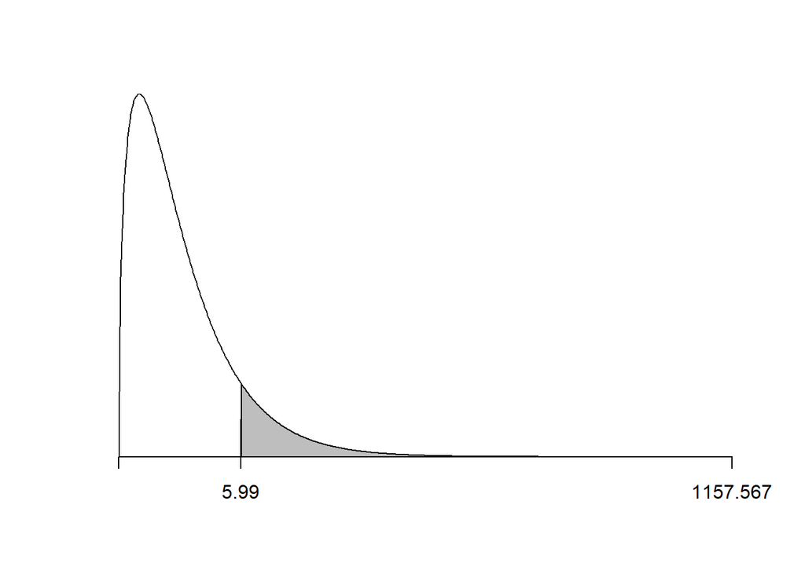

A través del valor “p”

```r
pvalue <- pchisq(chi_calc, df = df, lower.tail = F)
pvalue
```

```
[1] 4.341121e-252
```

- `lower.tail`: F o FALSE, siempre en Pruebas de Independencia

Alternativa 2: a través de la funcion `chisq.test()` del paquete base de R

```r
chisq.test(obs)
```

```
    Pearson's Chi-squared test

data:  obs
X-squared = 1157.6, df = 2, p-value < 2.2e-16
```

5. Conclusión COMPLETA:
- Si concluyo con los valores críticos:

Existe evidencia suficiente para rechazar la $H_0$, ya que el estadístico de prueba se encuentra en la región de rechazo, por lo tanto las variables **no son independientes**, hay una relación entre la aplicación de las vacunas y que el animal desarrolle o no la enfermedad.

- Si concluyo con el valor $p$:

Existe evidencia suficiente para rechazar la $H_0$, ya que el valor $p$ (4.341120710^{-252}) es menor al nivel de significancia ($\alpha$), por lo tanto las variables **no son independientes**, hay una relación entre la aplicación de las vacunas y que el animal desarrolle o no la enfermedad.

# Prueba de Homogeneidad

Es una prueba de la afirmación de que diferentes poblaciones tienen las mismas proporciones de algunas características.

**Estadístico de Prueba para todas las pruebas mencionas:**

$$\chi^2 = \sum\sum { \dfrac{ \left( o_{ij} - e_{ij} \right)^2}{e_{ij}} }$$

*Aclaraciones:*

Las frecuencias esperadas se calculan asumiendo homogeneidad entre las poblaciones:

$$e_{ij} = n_{i \cdot} \left[ \dfrac{n_{\cdot j}}{n} \right]$$

- $n_i\cdot$: total fila
- $n_{\cdot j}$: total columna
- $n$: gran total

> Las pruebas de homogeneidad con una tabla de contingencia son siempre de cola derecha.

## Ejercicio 2

La aplicación de curasemillas, es el factor clave en el arranque inicial para tener un cultivo sano desde el comienzo. Para el caso del cultivo de trigo, existe una gran variedad de curasemillas en el mercado. Se decide llevar a cabo un ensayo en donde se tomaron muestras de trigo y se les aplicó los curasemillas de las tres marcas más reconocidas del mercado, 100 semillas de cada marca, las denominadas CUR1, CUR2 y CUR3. Luego se las llevó a cámaras de germinación y se contabilizó cuantas plantulas desarrollaron o no enfermedades que debería haber protegido el curasemilla.

```
           Enfermedades
Curasemilla no si
       CUR1 31 69
       CUR2 15 85
       CUR3 13 87
```

Responda:

1. Cuál es la variable respuesta en estudio? Cuáles son las variables de clasificación?
2. Qué tipo de prueba se pretende analizar?
3. Plantee las hipótesis correspondientes, resuelva y concluya con un nivel de significancia del 0.05.

Importamos los datos:

```r
# Datos
txt<- textConnection(
"Curasemilla    Enfermedades    Cantidad
CUR1    si  69
CUR1    no  31
CUR2    si  85
CUR2    no  15
CUR3    si  87
CUR3    no  13")
cur <- read.table(txt, header = T)

# Tabla frecuencias: obs (observados)
obs <- xtabs(Cantidad ~ Curasemilla + Enfermedades, cur)

# Agregar márgenes (suma de filas y columnas)
addmargins(obs)
```

```
           Enfermedades
Curasemilla  no  si Sum
       CUR1  31  69 100
       CUR2  15  85 100
       CUR3  13  87 100
       Sum   59 241 300
```

### Item (a).

**Cuál es la variable respuesta en estudio? Cuáles son las variables de clasificación?**

La **variable respuesta** es **cantidad de plantulas enfermas**

Las **variables de clasificación** son:

- curasemillas: producto aplicado a cada muestra de 100 semillas
- enfermedades: indicando si cada plantula desarrolló o no enfermedades

### Item (b).

**Qué tipo de prueba se pretende analizar?**

Se desea hacer una prueba de Homogeneidad, ya que se desea estudiar en las tres muestras de marcas evaluadas, si desarrollaron o no enfermedades (tres muestras, un atributo).

### Item (c).

**Plantee las hipótesis correspondientes, resuelva y concluya con un nivel de significancia del 0.05.**

*Seguiremos los pasos de una PH:*

1. Definir las hipótesis

$H_0$: El desarrollo de enfermedades en plantulas de trigo es **homogéneo** en las tres marcas evaluadas.

$H_1$: El desarrollo de enfermedades en plantulas de trigo es **no es homogéneo** en las tres marcas evaluadas.

2. Determinar el valor del estadístico de prueba

Asumiendo $H_0$, cada $e_{ij}$ se calcula usando el mejor estimador de $p_{\cdot j}$, por lo tanto: $e_{ij}= n_{i \cdot} \left[ \dfrac{n_{\cdot j}}{n} \right]$

El estadístico de prueba es: $\chi^2 = \sum\sum { \dfrac{ \left( o_{ij} - e_{ij} \right)^2}{e_{ij}} }$

*Recordar: margen 1 es el total de filas y margen 2 es el total de columnas*

```r
# Valores esperados: esp
n <- margin.table(obs)

# vectores con los márgenes
n1 <- margin.table(obs, margin = 1)
n2 <- margin.table(obs, margin = 2)

#multiplicamos los valores de los vectores (total fila*totalcolumna/n)
esp <- (n1 %*% t(n2))/ n
esp
```

```
           Enfermedades
Curasemilla       no       si
       CUR1 19.66667 80.33333
       CUR2 19.66667 80.33333
       CUR3 19.66667 80.33333
```

```r
# Estadístico de prueba
chi_calc <- sum((obs-esp)^2/esp)
chi_calc
```

```
[1] 12.32154
```

- `%*%`: multiplica vectores (producto matricial)
- `t()`: es para “transponer” el vector, en éste caso “n2”
3. Determinar de la distribución muestral que se utilizará para la prueba de hipótesis

Se utilizará la distribución $\chi^2$ (Chi cuadrada)

4. Identificación de un valor $p$ y/o el(los) valor(es) crítico(s)

Alternativa 1:

A través del valor crítico (uno sólo porque se trabaja con cola derecha)

```r
alfa <- 0.05
df <- (nrow(esp) -1) * (ncol(esp) - 1)
chi_crit <- qchisq(alfa, df, lower.tail = F)
chi_crit
```

```
[1] 5.991465
```

- `nrow`: cantidad de filas
- `ncol`: cantidad de columnas
- `qchisq()`: `p = alfa` y `lower.tail = F`, siempre en en Pruebas de Homogeneidad

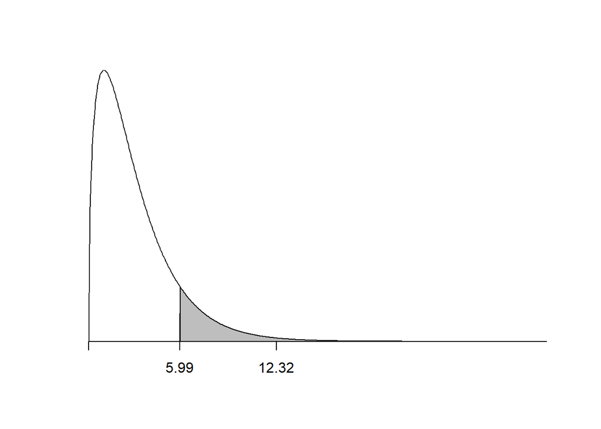

A través del valor “p”

```r
pvalue <- pchisq(chi_calc, df = df, lower.tail = F)
pvalue
```

```
[1] 0.002110626
```

- `lower.tail`: F o FALSE, siempre en Pruebas de Homogeneidad

Alternativa 2: a través de la funcion `chisq.test()` del paquete base de R

*Recordar: margen 1 es para las filas y margen 2 para las columnas*

```r
# Tabla frecuencias relativas
prop <- prop.table(obs)

# Proporciones marginales: margen que corresponda
p <- margin.table(prop, margin = 2)

chisq.test(obs, p = p)
```

```
    Pearson's Chi-squared test

data:  obs
X-squared = 12.322, df = 2, p-value = 0.002111
```

*En éste caso `margin` es = 2 porque quiero calcular las proporciones marginales de las columnas porque está la variable “Enfermedades” (siempre el margen del atributo).*

5. Conclusión COMPLETA:
- Si concluyo con los valores críticos:

Existe evidencia suficiente para rechazar la $H_0$, ya que el estadístico de prueba se encuentra en la región de rechazo, por lo tanto el desarrollo de enfermedades en plantulas de trigo es **no homogéneo** en las tres marcas evaluadas.

- Si concluyo con el valor $p$:

Existe evidencia suficiente para rechazar la $H_0$, ya que el valor $p$ (0.0021106) es menor al nivel de significancia ($\alpha$), por lo tanto el desarrollo de enfermedades en plantulas de trigo es **no homogéneo** en las tres marcas evaluadas.

# Prueba Bondad de Ajuste

La prueba de bondad de ajuste se utiliza para probar la hipótesis de que una distribución de frecuencias se ajusta a (o coincide con) alguna distribución.

- Si todas las frecuencias esperadas son iguales, entonces cada frecuencia esperada es la suma de todas las frecuencias observadas dividida entre el número de categorías, de manera que $E=n/r$.
- Si las frecuencias esperadas no son todas iguales, entonces cada frecuencia esperada se calcula multiplicando la suma de todas las frecuencias observadas por la probabilidad para la categoría, de manera que $E = n*p$ para cada categoría

Supuestos:

1. Los datos se seleccionaron al azar.
2. Los datos muestrales consisten en conteos de frecuencias para cada una de las diferentes categorías.

Valores críticos:

1. Los valores críticos se buscan con $r-g-1$ grados de libertad
2. Las pruebas de hipótesis por bondad de ajuste **siempre** son de cola derecha

*Aclaraciones:*

- $r$: número de categorías diferentes o resultados
- $g$: número de parámetros que se debieron estimar
- $n$: número total de ensayos

> Las pruebas de bondad de ajuste son siempre de cola derecha.

## Ejercicio 3

Un entomólogo interesado en estudiar ácaros en manzanos, seleccionó al azar 50 hojas de cada uno de 10 manzanos similares en una plantación del Centro de Santa Fe, examinó las hojas y registró el número de ácaros en cada una de las 500 hojas. Quería simular la distribución de los ácaros en los árboles de la plantación. Por lo tanto, se sugirió la distribución de Poisson como un posible modelo. Se desea saber con los datos obtenidos, si la distribución de Poisson parece ser un modelo apropiado de la distribución de ácaros en manzanos.

```
ácaros frecuencia
     0        233
     1        127
     2         57
     3         33
     4         30
     5         10
     6          7
     7          3
```

Responda:

1. Cuál es la variable respuesta en estudio?
2. Qué tipo de prueba se pretende analizar?
3. Plantee las hipótesis correspondientes, resuelva y concluya con un nivel de significancia del 0.05.

### Item (a).

**Cuál es la variable respuesta en estudio?**

La **variable respuesta** es **cantidad de ácaros por hoja**

### Item (b).

**Qué tipo de prueba se pretende analizar?**

Se desea hacer una prueba de Bondad de Ajuste, ya que se desea probar si la distribución de ácaros en manzanos sigue una distribución de Poisson.

### Item (c).

**Plantee las hipótesis correspondientes, resuelva y concluya con un nivel de significancia del 0.05.**

*Seguiremos los pasos de una PH:*

1. Definir las hipótesis

$H_0:$ La distribución de ácaros en manzanos se ajusta a una distribución de Poisson.

$H_1:$ La distribución de ácaros en manzanos no se ajusta a una distribución de Poisson.

2. Determinar el valor del estadístico de prueba

Asumiendo $H_0$, cada $e_{i}$ se calcula con $p_i$ que sale de la distribución teórica, $e_{i} = n p_i = \lambda_i$

Estadístico de prueba: $\chi^2 = \sum_{i=1}^r \sum_{j=1}^c \dfrac{ \left( o_{ij} - e_{ij} \right)^2}{e_{ij}} \sim \chi^2_{r-g-1}$

*$g$ es el número de parámetros de la distribución*

```r
# Frec observadas
acaros <- c(0,1,2,3,4,5,6,7)
obs <- c(233,127,57,33,30,10,7,3)

# Promedio datos agrupados
lambda <- weighted.mean(x = acaros, w = obs)
lambda
```

```
[1] 1.146
```

```r
# Probabilidades
prob <- dpois(acaros, lambda = lambda)
prob
```

```
[1] 0.3179058529 0.3643201075 0.2087554216 0.0797445710 0.0228468196
[6] 0.0052364911 0.0010001698 0.0001637421
```

```r
# Esperados
esp <- sum(obs) * prob
esp
```

```
[1] 158.95292647 182.16005373 104.37771079  39.87228552  11.42340980
[6]   2.61824553   0.50008490   0.08187104
```

```r
# Estadístico de prueba
chi_calc <- sum((obs-esp)^2/esp)
chi_calc
```

```
[1] 313.4019
```

3. Determinar de la distribución muestral que se utilizará para la prueba de hipótesis

Se utilizará la distribución $\chi^2$ (Chi cuadrada)

4. Identificación de un valor $p$ y/o el(los) valor(es) crítico(s)

Alternativa 1:

A través del valor crítico (uno sólo porque se trabaja con cola derecha)

```r
alfa <- 0.05
m <- 1         # cantidad de parametros que se estimaron: lambda

df <- length(obs) - m - 1

chi_crit <- qchisq(p = alfa, df = df, lower.tail = F)
chi_crit
```

```
[1] 12.59159
```

- `qchisq()`: `p = alfa` y `lower.tail = F`, siempre en Pruebas de Bondad de Ajuste.

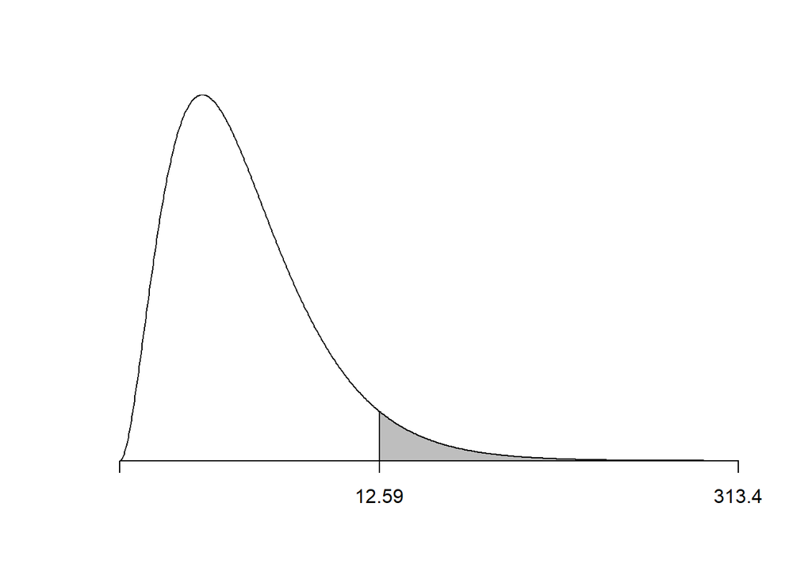

A través del valor “p”

```r
pvalue <- pchisq(chi_calc, df = df, lower.tail = F)
pvalue
```

```
[1] 1.097205e-64
```

- `lower.tail`: F o FALSE, siempre en Pruebas de Bondad de Ajuste

Alternativa 2: a través de la funcion `chisq.test()` del paquete base de R

```r
chisq.test(obs, p = prob, rescale.p = T)
```

```
Warning in chisq.test(obs, p = prob, rescale.p = T): Chi-squared
approximation may be incorrect
```

```
    Chi-squared test for given probabilities

data:  obs
X-squared = 313.39, df = 7, p-value < 2.2e-16
```

*No corrige los grados de libertad*

5. Conclusión COMPLETA:
- Si concluyo con los valores críticos:

Existe evidencia suficiente para rechazar la $H_0$, ya que el estadístico de prueba se encuentra en la región de rechazo, por lo tanto la distribución de ácaros en manzanos no se ajusta a una distribución de Poisson.

- Si concluyo con el valor $p$:

Existe evidencia suficiente para rechazar la $H_0$, ya que el valor $p$ (1.097204910^{-64}) es menor al nivel de significancia ($\alpha$), por lo tanto la distribución de ácaros en manzanos no se ajusta a una distribución de Poisson.

Material preparado por [Cátedra de Estadística FCA-UNL](https://github.com/estadistica-fca/)